# Ecommerce Funnel & Attribution Analysis

- Show All Code
- Hide All Code
- View Source

IBM 6530 · Submission Package

Authors

Bansi Khachar

Matthew Prado

Lucynda Young

Saurabh Parate

Published

May 6, 2026

# Project Deliverables

All deliverables for IBM 6530 are linked below. Click any link to open the published output.

| Deliverable | Link |
| --- | --- |
| 📊 Dashboard | [Google Analytics Client Dashboard](https://saurabhparate1619.github.io/shiny/Final%20Client%20Package.html) |
| 📄 Full Report | [Final Client Analytics Report](https://saurabhparate1619.github.io/shiny/Final%20Quarto%20Report) |
| 🎞️ Presentation | [Ecommerce Funnel & Attribution Analysis](https://saurabhparate1619.github.io/shiny/Deliverable_3_Presentation%201.html) |
| 💻 Source Code | [GitHub Repository](https://github.com/MattPradoCalPoly/project-IBM6530) |

# 1 Dashboard

**[Google Analytics Client Dashboard →](https://saurabhparate1619.github.io/shiny/Final%20Client%20Package.html)**

The interactive Looker Studio / Quarto dashboard provides stakeholders with a live view of key ecommerce KPIs, funnel stage performance, and session-level event breakdowns drawn from the GA4 BigQuery public dataset (Jan 31, 2021 snapshot).

# 2 Quarto Report

**[Final Client Analytics Report →](https://saurabhparate1619.github.io/shiny/Final%20Quarto%20Report)**

The full reproducible report below covers the complete analytical workflow, from raw BigQuery data ingestion through funnel analysis and Markov Chain attribution modelling, and concludes with prioritised recommendations.

## 2.1 Business Context

An ecommerce platform recorded **2,546 distinct users** and **26,489 total events** on a single day, yet completed only **17 purchases** — a conversion rate of **0.7%**. The platform averages roughly 10 events per user per session, indicating that engagement is not the problem; the bottleneck is conversion.

## 2.2 Core KPIs

```r
data.frame(
  Metric  = c("Total Events", "Distinct Users", "Sessions with Purchase", "Overall CVR"),
  Value   = c("26,489", "2,546", "17", "0.7%")
) |>
  kable(align = c("l", "r"), col.names = c("Metric", "Value")) |>
  kable_styling(bootstrap_options = c("striped", "hover"), full_width = FALSE) |>
  row_spec(4, bold = TRUE, color = "#991B1B")
```

| Metric | Value |
| --- | --- |
| Total Events | 26,489 |
| Distinct Users | 2,546 |
| Sessions with Purchase | 17 |
| Overall CVR | 0.7% |

## 2.3 Funnel Performance

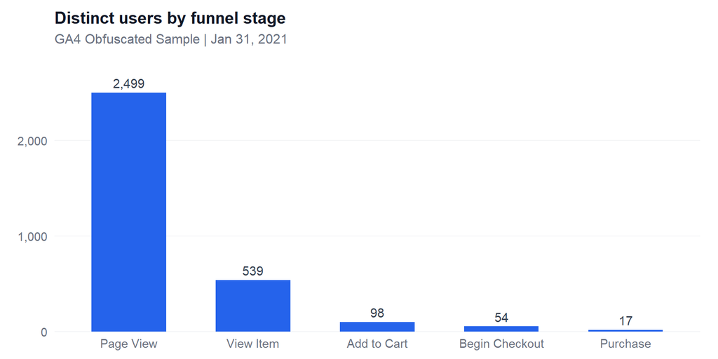

```r
ggplot(funnel, aes(x = event_name, y = users)) +
  geom_col(fill = C_BLUE, width = 0.6) +
  geom_text(aes(label = scales::comma(users)),
            vjust = -0.5, size = 4, color = "#374151") +
  scale_x_discrete(labels = c("Page View", "View Item",
                               "Add to Cart", "Begin Checkout", "Purchase")) +
  scale_y_continuous(labels = scales::comma,
                     expand  = expansion(mult = c(0, 0.15))) +
  labs(title    = "Distinct users by funnel stage",
       subtitle = "GA4 Obfuscated Sample | Jan 31, 2021") +
  theme_slide()
```

## 2.4 Drop-off Analysis

```r
data.frame(
  Stage    = c("page_view → view_item",
               "view_item → add_to_cart",
               "add_to_cart → begin_checkout",
               "begin_checkout → purchase"),
  Dropoff  = c("78.4%", "81.8%", "44.9%", "68.5%"),
  Priority = c("Critical", "Critical", "Moderate", "Critical")
) |>
  kable(align = c("l", "c", "c"),
        col.names = c("Transition", "Drop-off Rate", "Priority")) |>
  kable_styling(bootstrap_options = c("striped", "hover"), full_width = TRUE) |>
  row_spec(c(1, 2, 4), color = "#a32d2d", bold = TRUE) |>
  row_spec(3, color = "#b45309")
```

| Transition | Drop-off Rate | Priority |
| --- | --- | --- |
| page_view → view_item | 78.4% | Critical |
| view_item → add_to_cart | 81.8% | Critical |
| add_to_cart → begin_checkout | 44.9% | Moderate |
| begin_checkout → purchase | 68.5% | Critical |

**Important**

3 of 4 transitions have drop-off rates above 68%. The **product detail page** and the **checkout experience** are the two highest-priority fixes.

## 2.5 Attribution Analysis

### 2.5.1 Methodology

Attribution was performed at the session level using `user_pseudo_id` as the unit of analysis. All five funnel events were treated as touchpoints. A first-order **Markov Chain** model was selected over first-touch and last-touch heuristics because it accounts for the full customer journey by distributing credit based on each stage’s *removal effect* — the drop in conversion probability when that stage is removed from the path.

### 2.5.2 Markov Chain Results

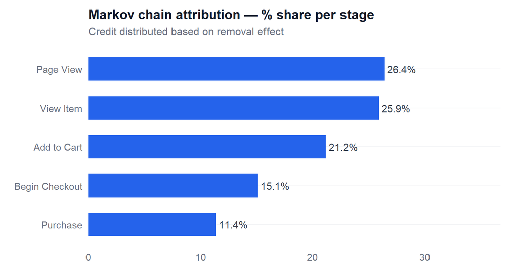

```r
table_markov |>
  mutate(channel = factor(channel, levels = funnel_order)) |>
  arrange(channel) |>
  ggplot(aes(x = reorder(channel, percent), y = percent)) +
  geom_col(fill = C_BLUE, width = 0.6) +
  geom_text(aes(label = paste0(percent, "%")),
            hjust = -0.1, size = 4, color = "#374151") +
  coord_flip() +
  scale_y_continuous(limits = c(0, 35),
                     expand  = expansion(mult = c(0, 0.05))) +
  scale_x_discrete(labels = c("purchase"       = "Purchase",
                               "begin_checkout" = "Begin Checkout",
                               "add_to_cart"    = "Add to Cart",
                               "view_item"      = "View Item",
                               "page_view"      = "Page View")) +
  labs(title    = "Markov chain attribution — % share per stage",
       subtitle = "Credit distributed based on removal effect") +
  theme_slide()
```

`page_view` and `view_item` together account for **52.3%** of total conversion credit, confirming that top-of-funnel investment has the highest marginal return.

### 2.5.3 Model Comparison

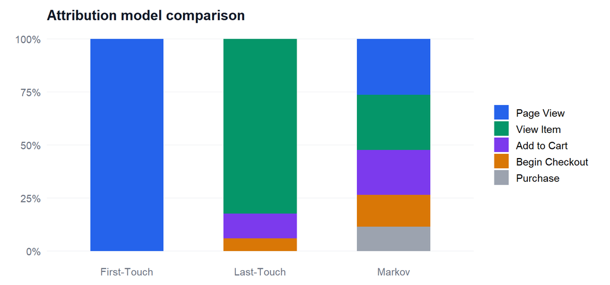

```r
comparison <- data.frame(
  channel = rep(c("Page View", "View Item", "Add to Cart",
                  "Begin Checkout", "Purchase"), 3),
  model   = rep(c("First-Touch", "Last-Touch", "Markov"), each = 5),
  value   = c(
    100,  0,    0,    0,   0,
    0,    82.4, 11.8, 5.9, 0,
    26.4, 25.9, 21.2, 15.1, 11.4
  )
) |>
  mutate(
    channel = factor(channel,
                     levels = c("Page View", "View Item", "Add to Cart",
                                "Begin Checkout", "Purchase")),
    model   = factor(model, levels = c("First-Touch", "Last-Touch", "Markov"))
  )

ggplot(comparison, aes(x = model, y = value, fill = channel)) +
  geom_col(position = "fill", width = 0.55) +
  scale_y_continuous(labels = percent_format()) +
  scale_fill_manual(values = c(
    "Page View"      = "#2563EB",
    "View Item"      = "#059669",
    "Add to Cart"    = "#7C3AED",
    "Begin Checkout" = "#D97706",
    "Purchase"       = "#9CA3AF"
  )) +
  labs(title = "Attribution model comparison",
       x = NULL, y = "Share", fill = NULL) +
  theme_slide() +
  theme(legend.position = "right",
        legend.text = element_text(size = 11))
```

## 2.6 Recommendations

| Priority | Area | Action | Expected Impact |
| --- | --- | --- | --- |
| 1 | Landing page | Feature products above the fold; A/B test homepage layout | +250 users into funnel |
| 2 | Product detail page | Add reviews & urgency signals; rewrite benefit-led copy | +54 add-to-cart users |
| 3 | Checkout | Enable guest checkout; reduce form fields; add trust badges | CVR 0.7% → 1.1% |

## 2.7 Limitations

- **Single-day snapshot** — results are directional only; seasonal and campaign effects are unaccounted for.
- **Anonymized users** — `user_pseudo_id` does not persist across devices, inflating the distinct user count.
- **No channel data** — paid vs. organic vs. direct conversion rates cannot be compared.
- **Small sample** — 17 purchases carries high statistical uncertainty; validate over 30+ days before acting.
- **Shapley values undefined** — identical converting paths leave no variance for marginal contribution calculation.

## 2.8 Next Steps

**Short term (0–30 days):** Implement homepage A/B test · Add reviews to top 10 product pages · Enable guest checkout

**Medium term (30–90 days):** Collect 30 days of data for reanalysis · Implement consistent `user_id` tagging

**Long term (90+ days):** Integrate CRM and campaign data into BigQuery · Run full Markov attribution with 100+ conversions · Build channel-level ROI model

# 3 Presentation

**[Ecommerce Funnel & Attribution Analysis — Presentation →](https://saurabhparate1619.github.io/shiny/Deliverable_3_Presentation%201.html)**

The slide deck covers the business problem, project objectives, data & methodology, funnel performance, drop-off analysis, Markov Chain attribution, model comparison, recommendations, limitations, and next steps.

## 4 Appendix

## 4.1 GitHub Repository

All source code, data preparation scripts, BigQuery SQL, and rendered outputs are version-controlled and publicly available:

**github.com/MattPradoCalPoly/project-IBM6530**

The repository contains:

- `data/` — cleaned BigQuery export (CSV)
- `report/` — Quarto report source (`.qmd`) and rendered HTML
- `presentation/` — Quarto revealjs presentation source
- `dashboard/` — Looker Studio configuration and Quarto dashboard source
- `R/` — standalone R analysis script with all plots and tables
- `sql/` — BigQuery mart queries used to build the funnel and attribution datasets